# Caring for Your Mental Health During India’s COVID-19 Surge

Last updated: May 21, 2021

*Disclaimer: This document is managed by [what_a_sham](https://www.instagram.com/what_a_sham/), who is not a mental health care professional. This is a community project to help citizens in a time of need. This document contains a compilation of links, and material from cited sources. If you want to help expand or improve this page, please get in touch with [what_a_sham](https://www.instagram.com/what_a_sham/) (Instagram) or send a pull request (Github).*

## If you are in need of immediate help

**Behavioural Health: Psycho-Social Toll free helpline (India) – 08046110007 (MOHFW – all days)**

Other helpline numbers:

- Aasra – (numbers also by state on website): http://www.aasra.info/helpline.html - +91 9820466726 - (24 hours)
- iCall: https://icallhelpline.org/ - +91 9152987821 - (10am - 8pm Monday to Saturday)
- Mpower: https://mpowerminds.com/oneonone - 1800-120-820050 (24 hours)
- Parivarthan - https://parivarthan.org/ - +91 7676602602 - (1pm – 10pm Monday to Friday)
- Sneha - https://snehaindia.org/new/ - +91 44 24640050 - (10am – 10pm all days)

**If you are in need of therapy/counseling, but are unable to find help, fill out this form and [what_a_sham](https://www.instagram.com/what_a_sham/) will get in touch with you to find a resource person or mental health professional.** [[LINK](https://forms.gle/1BwEE94jK5uoBAtX6)]

*If you are a social worker or clinical psychologist, please DM [what_a_sham](https://www.instagram.com/what_a_sham/) in order to help or volunteer.*

## Understanding Stress and Anxiety

Many of us and our friends may be facing stress and trauma because of the pandemic. Whether you are suffering from the illness during this time, caring for one, facing loss of family, or just feel helpless hearing the news of loss around you, COVID-19 can affect your mental health in multiple ways.

Make sure to check on your friends and ensure they are healthy mentally during this time. This would be applicable specifically TO older people in your family, domestic staff, and those less privileged who often brush off these problems.

Caring for your mental health and of those around you can help you become more resilient. Taking care of yourself can also help you care better for others.

### Stress can manifest itself in the following ways

From [Centers for Disease Control and Prevention](https://www.cdc.gov/coronavirus/2019-ncov/daily-life-coping/managing-stress-anxiety.html)

> 1. Feelings of fear, anger, sadness, worry, numbness, or frustration.
> 2. Changes in appetite, energy, desires, and interests.
> 3. Difficulty concentrating and making decisions.
> 4. Difficulty sleeping or nightmares.
> 5. Physical reactions, such as headaches, body pains, stomach problems, and skin rashes.
> 6. Worsening of chronic health problems.
> 7. Worsening of mental health conditions.
> 8. Increased use of tobacco, alcohol, and other substances.

### Mental Health Matters

[Video from Ministry of Health and Family Welfare](https://www.youtube.com/watch?v=rJENzEE4xBE) (July 2020)

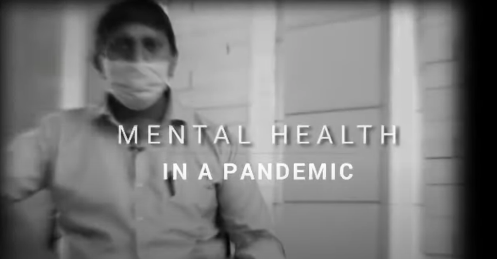

### Where in your body is *stress*?

From [Doing What Matters in Times of Stress](https://apps.who.int/iris/bitstream/handle/10665/331901/9789240003910-eng.pdf?sequence=1&isAllowed=y)

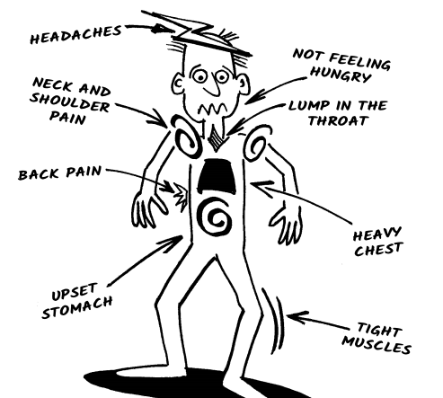

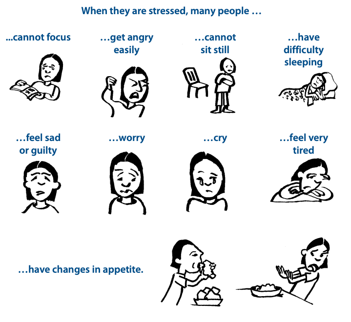

## Self-care

Here are some things you can do on your own and tell others to do:

### Yoga for stress

From [MOHFW](https://www.mohfw.gov.in/pdf/HCWMentalHealthSupportGuidanceJuly20201.pdf)

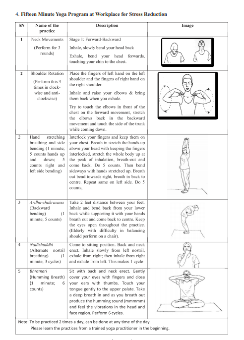

Video on Yoga for Stress Management (instructions in English and Hindi) From [NIMHANS](https://www.youtube.com/watch?v=qsK7SAfajoM)(April 2020)

[figure not shown]

### App based meditation

1. Wysa - made their modules free because of the pandemic [Download app.](https://www.wysa.io/)
2. Headspace – 10 min meditation to reframe stress [(video)](http://youtube.com/watch?v=sG7DBA-mgFY). [Download app.](https://www.headspace.com/headspace-meditation-app)
3. Calm – Take a deep breath [(video playlist)](https://www.youtube.com/watch?v=zilmlTO5i9Q&list=PLgdxvG3Ulbie6EIEToXVPV73_Zf2DiCLl). [Download app.](https://www.calm.com/)

### Tips to manage stress

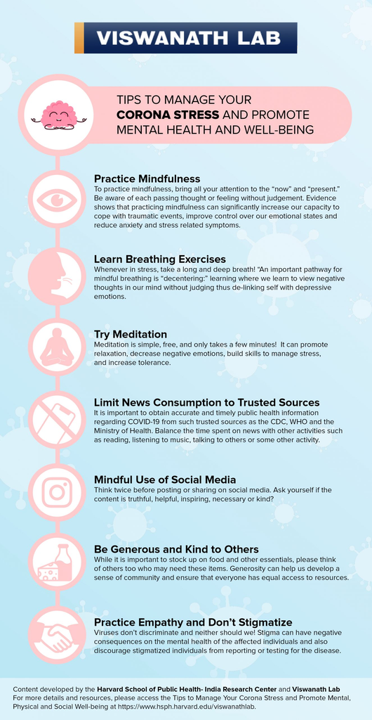

### Grounding

Imagine you are in a tree during a storm. Up at that height it may be difficult for you to be safe. It is much safer to be on the "ground".

By bringing our mind and our body back to the present moment, we can sometimes allow ourselves the space for our brain to slow down and feel a bit more centered, at least enough so we can let someone know what's going on or that we need help, or figure out what to do next.

Here are some steps you can follow for grounding if you are feeling intense emotions.  
From [The Growlery](http://www.tothegrowlery.com/blog/2017/4/18/six-different-types-of-grounding-exercises-for-anxiety-intense-emotions)

[figure not shown]

## How to talk to someone dealing with COVID-19 related stress

Your friends and family may reach out to you to talk about what they are feeling. Here are some things to keep in mind.

From [National Institute of Mental Health and Neurosciences](http://nimhans.ac.in/wp-content/uploads/2020/05/Resource-Material-for-providing-basic-psychological-support-in-the-context-of-COVID19.pdf) (adapted for use by non-professionals)

**Try these:**

1. Use open ended questions – *How are you feeling?*
2. Permit them to express distressing thoughts and feelings – *Please tell me more about it…*
3. Listen actively – *This must be difficult…*
4. Validate their feelings related to the situation – *These are challenging times and many things are not under our control. It is natural to feel sad/ anxious/ helpless/ stressed.*
5. Shift their focus to those things that are under their control – *Are there other aspects in your current situation that are more manageable and can make you feel more in control of your life?*

**Also do:**

1. Appreciate them for reaching out for help at such times.
2. Jointly explore what they can and would like to do to make themselves feel better.
3. Encourage them to reach out to professionals if problems persist. Let them know they shouldn’t feel stigmatized.

**Avoid these:**

1. Trivializing a person’s experiences and feeling – *It’s a small thing. Don’t bother.*
2. Interrupting the person or offering solutions when the person just wants to share feelings/thoughts.
3. Giving advice that may be difficult to follow. They may be limited in supplies or space.
4. Offering too many suggestions/solutions within a brief span of time.
5. Providing personal opinions or information that you are not sure about or lack the qualifications for.
6. Be aware of your biases. Do not let them come in the way when you are offering support to someone in distress.

## Get in touch with mental health professionals

You can contact the persons mentioned here directly and schedule a conversation with them. You can also fill out the form and we will get in touch with you. [[LINK](https://forms.gle/1BwEE94jK5uoBAtX6)]

1. [Mrigtrishna Rathore](https://www.instagram.com/mrigtrishna_rathore/) - *Pay what you can therapy sessions*  
   Contact: [Instagram](https://www.instagram.com/mrigtrishna_rathore/)
2. [Prachi Desai Shah](https://www.instagram.com/prachidesai1410/)  
   Contact: Email - prachidesaishah@gmail.com, Phone - +91 99875 94548

### Other low-cost therapy

1. Therapy Fund: 2 free sessions per person. [FORM LINK](https://docs.google.com/forms/d/e/1FAIpQLSchCS_tnuYVDRpYUbr1SDeQgKgGV6bXkn_04KvzvJSweMjqng/viewform)
2. Therapize.india: Free 1:1 online counseling sessions conducted in English. Registration open beginning of the week. [REGISTRATION LINK](https://calendly.com/therapize/probono?month=2021-05) **NO DATES IN MAY**
3. [Dr. Prerna Kohli](https://www.instagram.com/drprernakohli.in/): One session of free counseling, by associates of Dr. Kohli, after which you can take additional counseling at very nominal charges.  
   [REGISTRATION LINK](https://www.mindtribe.in/free-counseling)
4. [With Love We Care](https://withlovewecare.in/): Free mental health support.  
   Email: info@withlovewecare.in, WhatsApp: +91 9771413646. Time: 10am-12pm, 5pm-9pm
5. [Mind Wellness India](http://mindwellnessindia.com/): **Free counseling for frontline workers**.  
   Email - mindwellnesscounselling@gmail.com, SMS: +91 9830463635
6. [The Sister's Block](https://www.instagram.com/we.thesistersblock/): Counseling service at Rs. 100 per session.  
   [REGISTRATION LINK](https://forms.gle/PGP2KGCMjjj8XHQD8)
7. [Reality And You](https://www.instagram.com/realityandyoufoundation/): Offering free counselling services and funding free medical services for the lower socioeconomic groups.  
   [LINK TO SUPPORT GROUP FOR PRETEENS](https://docs.google.com/forms/d/1N1iB-0OBlwTFHXkKp5rzimLk8sBl_cBbhc1i1dCHXYw/viewform?ts=6088fd70&edit_requested=true)

## For healthcare and other institutions

### How to support your staff

From [Inter-Agency Standing Committee](https://interagencystandingcommittee.org/iasc-reference-group-mental-health-and-psychosocial-support-emergency-settings/iasc-guidance-basic-psychosocial-skills-guide-covid-19-responders)

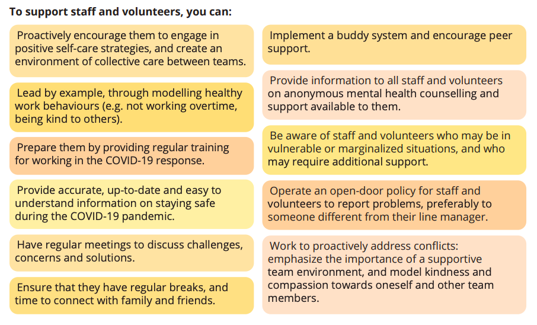

## Important Resources

Some resources you can read to get a better understanding of how to get help for yourself and offer help to others:

1. [Doing What Matters in Times of Stress](https://apps.who.int/iris/bitstream/handle/10665/331901/9789240003910-eng.pdf?sequence=1&isAllowed=y) (WHO) – *Illustrated guide on dealing with stress*
2. CDC guidelines on [Coping with Stress](https://www.cdc.gov/coronavirus/2019-ncov/daily-life-coping/managing-stress-anxiety.html) – *compilation of resources and tips*
3. **Conversations can help** – Here is [*how to have conversations with others*](https://howrightnow.org/talk) (video)
4. Tips to face [COVID related anxiety](https://www.allencomm.com/courses/covid19_5_tips_to_face_your_anxiety/index.html) – *5 tips on dealing with anxiety*
5. Caring for older [adult’s mental health](https://afsp.org/story/covid-19-we-must-care-for-older-adults-mental-health) – *short article (3 mins)*
6. Emotional and [spiritual care](https://3hb3e83lj75i1iikjx1wkj2o-wpengine.netdna-ssl.com/wp-content/uploads/light_our_way_2018_final-published-copy.pdf) during disaster – *guide for volunteers and responders*
7. Managing family [conflict with intimate partners](https://www.cstsonline.org/assets/media/documents/CSTS_FS_Managing_Family_Conflict_While_Home.pdf) – *2-page pamphlet with tips*
8. Protecting [early childhood impacts](https://developingchild.harvard.edu/resources/protecting-our-children-covid-19s-impact-on-early-childhood-and-aces/?utm_source=newsletter&utm_medium=email&utm_campaign=september_2020) - *webinar*
9. Supporting [children and yourself](https://46y5eh11fhgw3ve3ytpwxt9r-wpengine.netdna-ssl.com/wp-content/uploads/2020/04/COVID-19_for_families_FINAL.pdf) – *3-page handout*
10. **For parents**: [families and children](https://childmind.org/coping-during-covid-19-resources-for-parents/) – *collection of resources*
11. Helping [family with stress](https://www.atsdr.cdc.gov/emes/health_professionals/documents/relocationstress_508.pdf) – *short handout*
12. **For healthcare workers**: [Self-Care Modules](https://files.asprtracie.hhs.gov/documents/aspr-tracie-dbh-self-care-for-healthcare-workers-modules-description-final-8-19-19.pdf) – *handout with links to important resources*
13. [Managing mental illness in Hospitals](https://www.mohfw.gov.in/pdf/GuidelinesforDeliveryofMentalMentalHealthcareServicesduringtheCOVID19.pdf) – *MOHFW guideline*
14. [Guide for general medical and mental healthcare settings](https://www.mohfw.gov.in/pdf/COVID19Final2020ForOnline9July2020.pdf) – *MOHFW guideline*
15. **For community leaders**: [Grief leadership](https://www.cstsonline.org/assets/media/documents/CSTS_FS_Grief_Leadership_During_COVID19.pdf) – *2-page pamphlet with tips*
16. **For faith leader**: *webinar* on [mental health and anxiety management](https://www.youtube.com/watch?v=8HJ7q-xs7_U)
17. Resources for [mental health management](https://www.mhinnovation.net/cross-cutting-resources) for organizations - *collection of useful links and official documents*
18. [A Guide for COVID-19 Responders](https://interagencystandingcommittee.org/iasc-reference-group-mental-health-and-psychosocial-support-emergency-settings/iasc-guidance-basic-psychosocial-skills-guide-covid-19-responders) in multiple languages - *26-page guide with case examples and illustrations*. Also in [Hindi](https://interagencystandingcommittee.org/system/files/2021-02/Basic%20Psychosocial%20Skills-%20A%20Guide%20for%20COVID-19%20Responders%20%28Hindi%29.pdf)
19. [Psychosocial Care for Frontline Health Care Worders](https://nimhans.ac.in/wp-content/uploads/2021/04/FHW-Manual-Final.pdf)(NIMHANS) - *comprehensive information manual*

## Donate to MH Campaigns

1. Support Mental Health Needs of Covid-19 Workers - by One Future Collective  
   Campaign - [LINK](https://www.ourdemocracy.in/Campaign/covid19mentalhealth)  
   More information on [One Future Collective](https://drive.google.com/file/d/1KKsC1mKVpdM5bVbvEuqzydllfCh8T05h/view).
2. Therapy Fund India - Supoorting counseling for those who need it  
   Campaight - [LINK](https://milaap.org/fundraisers/support-therapy-fund-india)

## Volunteer: Virtual Volunteer with Project VK

Global Shapers, Dusseldorf has launched an initiative "Vasudhaiva Kutumbakamb - the World is one family" (Project VK). The vision of this initiative is to mobilize the youth, globally as well as Indians staying abroad, who, due to logistic reasons, cannot physically extend frontline help to India, but have the urge to reach out. We aim to train the volunteers in mental health first aid (training by professionals), followed by formation of multi-tiered support groups for guided mental rehabilitation of sufferers.

[LINK TO FORM](https://docs.google.com/forms/d/e/1FAIpQLSdHQoSKthqQhRfQhQorXUL4fhonzqZpoO1b-FXPH60-5rhSFw/viewform)

[figure not shown]